# Machine Learning Workflow: Model Stacking (Heart Data)

Biostat 203B

Author

Dr. Hua Zhou @ UCLA

Published

February 27, 2024

## 1 Setup

Display system information for reproducibility.

**R**

**Python**

```python
import IPython
print(IPython.sys_info())
```

**Julia**

```julia
using InteractiveUtils
versioninfo()
```

## 2 Overview

[figure not shown]

We illustrate the typical machine learning workflow for model stacking using the `Heart` data set. The outcome is `AHD` (`Yes` or `No`), using the [`stacks`](https://stacks.tidymodels.org/) package.

## 3 Heart data

The goal is to predict the binary outcome `AHD` (`Yes` or `No`) of patients.

**R**

```r
# Load libraries
library(GGally)
library(gtsummary)
library(keras)
library(ranger)
library(stacks)
library(tidyverse)
library(tidymodels)
library(xgboost)
# Load the `Heart.csv` data.
Heart <- read_csv("Heart.csv") |>
  # first column is patient ID, which we don't need
  select(-1) |>
  # RestECG is categorical with value 0, 1, 2
  mutate(RestECG = as.character(RestECG)) |>
  mutate(AHD = as.factor(AHD)) |>
  print(width = Inf)
```

```
──────────────────────────────────────────────────────── Delimiter: "," chr
(3): ChestPain, Thal, AHD dbl (12): ...1, Age, Sex, RestBP, Chol, Fbs, RestECG,
MaxHR, ExAng, Oldpeak,...
```

```
# A tibble: 303 × 14
     Age   Sex ChestPain    RestBP  Chol   Fbs RestECG MaxHR ExAng Oldpeak Slope
   <dbl> <dbl> <chr>         <dbl> <dbl> <dbl> <chr>   <dbl> <dbl>   <dbl> <dbl>
 1    63     1 typical         145   233     1 2         150     0     2.3     3
 2    67     1 asymptomatic    160   286     0 2         108     1     1.5     2
 3    67     1 asymptomatic    120   229     0 2         129     1     2.6     2
 4    37     1 nonanginal      130   250     0 0         187     0     3.5     3
 5    41     0 nontypical      130   204     0 2         172     0     1.4     1
 6    56     1 nontypical      120   236     0 0         178     0     0.8     1
 7    62     0 asymptomatic    140   268     0 2         160     0     3.6     3
 8    57     0 asymptomatic    120   354     0 0         163     1     0.6     1
 9    63     1 asymptomatic    130   254     0 2         147     0     1.4     2
10    53     1 asymptomatic    140   203     1 2         155     1     3.1     3
      Ca Thal       AHD
   <dbl> <chr>      <fct>
 1     0 fixed      No
 2     3 normal     Yes
 3     2 reversable Yes
 4     0 normal     No
 5     0 normal     No
 6     0 normal     No
 7     2 normal     Yes
 8     0 normal     No
 9     1 reversable Yes
10     0 reversable Yes
# ℹ 293 more rows
```

```r
# Numerical summaries stratified by the outcome `AHD`.
Heart |> tbl_summary(by = AHD)
```

| **Characteristic** | **No**, N = 164<sup>1</sup> | **Yes**, N = 139<sup>1</sup> |
| --- | --- | --- |
| Age | 52 (45, 59) | 58 (52, 62) |
| Sex | 92 (56%) | 114 (82%) |
| ChestPain |  |  |
| asymptomatic | 39 (24%) | 105 (76%) |
| nonanginal | 68 (41%) | 18 (13%) |
| nontypical | 41 (25%) | 9 (6.5%) |
| typical | 16 (9.8%) | 7 (5.0%) |
| RestBP | 130 (120, 140) | 130 (120, 145) |
| Chol | 235 (209, 267) | 249 (218, 284) |
| Fbs | 23 (14%) | 22 (16%) |
| RestECG |  |  |
| 0 | 95 (58%) | 56 (40%) |
| 1 | 1 (0.6%) | 3 (2.2%) |
| 2 | 68 (41%) | 80 (58%) |
| MaxHR | 161 (149, 172) | 142 (125, 157) |
| ExAng | 23 (14%) | 76 (55%) |
| Oldpeak | 0.20 (0.00, 1.03) | 1.40 (0.55, 2.50) |
| Slope |  |  |
| 1 | 106 (65%) | 36 (26%) |
| 2 | 49 (30%) | 91 (65%) |
| 3 | 9 (5.5%) | 12 (8.6%) |
| Ca |  |  |
| 0 | 130 (81%) | 46 (33%) |
| 1 | 21 (13%) | 44 (32%) |
| 2 | 7 (4.3%) | 31 (22%) |
| 3 | 3 (1.9%) | 17 (12%) |
| Unknown | 3 | 1 |
| Thal |  |  |
| fixed | 6 (3.7%) | 12 (8.7%) |
| normal | 129 (79%) | 37 (27%) |
| reversable | 28 (17%) | 89 (64%) |
| Unknown | 1 | 1 |

<sup>1</sup> Median (IQR); n (%)

```r
# Graphical summary:
# Heart |> ggpairs()
```

**Python**

TODO

### 3.1 Julia

TODO

## 4 Initial split into test and non-test sets

We randomly split the data into 25% test data and 75% non-test data. Stratify on `AHD`.

**R**

```r
# For reproducibility
set.seed(203)

data_split <- initial_split(
  Heart,
  # stratify by AHD
  strata = "AHD",
  prop = 0.75
  )
data_split
```

```
<Training/Testing/Total>
<227/76/303>
```

```r
Heart_other <- training(data_split)
dim(Heart_other)
```

```
[1] 227  14
```

```r
Heart_test <- testing(data_split)
dim(Heart_test)
```

```
[1] 76 14
```

**Python**

TODO

**Julia**

TODO

## 5 Recipe (R) and Preprocessing (Python)

- A data dictionary (roughly) is at https://keras.io/examples/structured_data/structured_data_classification_with_feature_space/.
- We have following features:
  - Numerical features: `Age`, `RestBP`, `Chol`, `Slope` (1, 2 or 3), `MaxHR`, `ExAng`, `Oldpeak`, `Ca` (0, 1, 2 or 3).
  - Categorical features coded as integer: `Sex` (0 or 1), `Fbs` (0 or 1), `RestECG` (0, 1 or 2).
  - Categorical features coded as string: `ChestPain`, `Thal`.
- There are missing values in `Ca` and `Thal`. Since missing proportion is not high, we will use simple mean (for numerical feature `Ca`) and mode (for categorical feature `Thal`) imputation.

**R**

```r
heart_recipe <-
  recipe(
    AHD ~ .,
    data = Heart_other
  ) |>
  # mean imputation for Ca
  step_impute_mean(Ca) |>
  # mode imputation for Thal
  step_impute_mode(Thal) |>
  # create traditional dummy variables (necessary for xgboost)
  step_dummy(all_nominal_predictors()) |>
  # zero-variance filter
  step_zv(all_predictors())
  # estimate the means and standard deviations
  # prep(training = Heart_other, retain = TRUE)
heart_recipe
```

```
── Recipe ──────────────────────────────────────────────────────────────────────
```

```
── Inputs
```

```
Number of variables by role
```

```
outcome:    1
predictor: 13
```

```
── Operations
```

```
• Mean imputation for: Ca
```

```
• Mode imputation for: Thal
```

```
• Dummy variables from: all_nominal_predictors()
```

```
• Zero variance filter on: all_predictors()
```

**Python**

TODO

### 5.1 Julia

TODO

## 6 Base models

We will use three different model definitions to try to classify the outcome `AHD`: logistic regression, random forest, and neural network.

First we set up the cross-validation folds to be shared by all models.

```r
set.seed(203)
folds <- vfold_cv(Heart_other, v = 5)
```

### 6.1 Logistic regression

Set up model.

**R**

```r
logit_mod <-
  logistic_reg(
    penalty = tune(),
    mixture = tune()
  ) |>
  set_engine("glmnet", standardize = TRUE)
logit_mod
```

```
Logistic Regression Model Specification (classification)

Main Arguments:
  penalty = tune()
  mixture = tune()

Engine-Specific Arguments:
  standardize = TRUE

Computational engine: glmnet
```

**Python**

TODO

**Julia**

TODO

Bundle the recipe (R) and model into workflow.

**R**

```r
logit_wf <- workflow() |>
  add_recipe(heart_recipe) |>
  add_model(logit_mod)
logit_wf
```

```
══ Workflow ════════════════════════════════════════════════════════════════════
Preprocessor: Recipe
Model: logistic_reg()

── Preprocessor ────────────────────────────────────────────────────────────────
4 Recipe Steps

• step_impute_mean()
• step_impute_mode()
• step_dummy()
• step_zv()

── Model ───────────────────────────────────────────────────────────────────────
Logistic Regression Model Specification (classification)

Main Arguments:
  penalty = tune()
  mixture = tune()

Engine-Specific Arguments:
  standardize = TRUE

Computational engine: glmnet
```

**Python**

TODO

**Julia**

TODO

Set up tuning grid

**R**

```r
logit_grid <- grid_regular(
  penalty(range = c(-6, 3)),
  mixture(),
  levels = c(100, 5)
  )

logit_res <-
  tune_grid(
    object = logit_wf,
    resamples = folds,
    grid = logit_grid,
    control = control_stack_grid()
  )
logit_res
```

```
# Tuning results
# 5-fold cross-validation
# A tibble: 5 × 5
  splits           id    .metrics             .notes           .predictions
  <list>           <chr> <list>               <list>           <list>
1 <split [181/46]> Fold1 <tibble [1,000 × 6]> <tibble [0 × 3]> <tibble>
2 <split [181/46]> Fold2 <tibble [1,000 × 6]> <tibble [0 × 3]> <tibble>
3 <split [182/45]> Fold3 <tibble [1,000 × 6]> <tibble [0 × 3]> <tibble>
4 <split [182/45]> Fold4 <tibble [1,000 × 6]> <tibble [0 × 3]> <tibble>
5 <split [182/45]> Fold5 <tibble [1,000 × 6]> <tibble [0 × 3]> <tibble>
```

**Python**

TODO

**Julia**

TODO

### 6.2 Random forest

Set up model.

**R**

```r
rf_mod <-
  rand_forest(
    mode = "classification",
    # Number of predictors randomly sampled in each split
    mtry = tune(),
    # Number of trees in ensemble
    trees = tune()
  ) |>
  set_engine("ranger")
rf_mod
```

```
Random Forest Model Specification (classification)

Main Arguments:
  mtry = tune()
  trees = tune()

Computational engine: ranger
```

**Python**

TODO

**Julia**

TODO

Bundle the recipe (R) and model into workflow.

**R**

```r
rf_wf <- workflow() |>
  add_recipe(heart_recipe) |>
  add_model(rf_mod)
rf_wf
```

```
══ Workflow ════════════════════════════════════════════════════════════════════
Preprocessor: Recipe
Model: rand_forest()

── Preprocessor ────────────────────────────────────────────────────────────────
4 Recipe Steps

• step_impute_mean()
• step_impute_mode()
• step_dummy()
• step_zv()

── Model ───────────────────────────────────────────────────────────────────────
Random Forest Model Specification (classification)

Main Arguments:
  mtry = tune()
  trees = tune()

Computational engine: ranger
```

**Python**

TODO

**Julia**

TODO

Set up tuning grid

**R**

```r
rf_grid <- grid_regular(
  trees(range = c(100L, 500L)),
  mtry(range = c(1L, 5L)),
  levels = c(5, 5)
  )

rf_res <-
  tune_grid(
    object = rf_wf,
    resamples = folds,
    grid = rf_grid,
    control = control_stack_grid()
  )
rf_res
```

```
# Tuning results
# 5-fold cross-validation
# A tibble: 5 × 5
  splits           id    .metrics          .notes           .predictions
  <list>           <chr> <list>            <list>           <list>
1 <split [181/46]> Fold1 <tibble [50 × 6]> <tibble [0 × 3]> <tibble [1,150 × 8]>
2 <split [181/46]> Fold2 <tibble [50 × 6]> <tibble [0 × 3]> <tibble [1,150 × 8]>
3 <split [182/45]> Fold3 <tibble [50 × 6]> <tibble [0 × 3]> <tibble [1,125 × 8]>
4 <split [182/45]> Fold4 <tibble [50 × 6]> <tibble [0 × 3]> <tibble [1,125 × 8]>
5 <split [182/45]> Fold5 <tibble [50 × 6]> <tibble [0 × 3]> <tibble [1,125 × 8]>
```

**Python**

TODO

**Julia**

TODO

### 6.3 Neural network

Set up model.

**R**

```r
mlp_mod <-
  mlp(
    mode = "classification",
    hidden_units = tune(),
    dropout = tune(),
    epochs = 50,
  ) |>
  set_engine("keras", verbose = 0)
mlp_mod
```

```
Single Layer Neural Network Model Specification (classification)

Main Arguments:
  hidden_units = tune()
  dropout = tune()
  epochs = 50

Engine-Specific Arguments:
  verbose = 0

Computational engine: keras
```

**Python**

TODO

**Julia**

TODO

Bundle the recipe (R) and model into workflow.

**R**

```r
mlp_wf <- workflow() |>
  add_recipe(heart_recipe) |>
  add_model(mlp_mod)
mlp_wf
```

```
══ Workflow ════════════════════════════════════════════════════════════════════
Preprocessor: Recipe
Model: mlp()

── Preprocessor ────────────────────────────────────────────────────────────────
4 Recipe Steps

• step_impute_mean()
• step_impute_mode()
• step_dummy()
• step_zv()

── Model ───────────────────────────────────────────────────────────────────────
Single Layer Neural Network Model Specification (classification)

Main Arguments:
  hidden_units = tune()
  dropout = tune()
  epochs = 50

Engine-Specific Arguments:
  verbose = 0

Computational engine: keras
```

**Python**

TODO

**Julia**

TODO

Set up tuning grid

**R**

```r
mlp_grid <- grid_regular(
  hidden_units(range = c(1, 20)),
  dropout(range = c(0, 0.6)),
  levels = 5
  )

mlp_res <-
  tune_grid(
    object = mlp_wf,
    resamples = folds,
    grid = mlp_grid,
    control = control_stack_grid()
  )
```

[output not shown]

[output cut: 195 more lines]

[output not shown]

```r
mlp_res
```

```
# Tuning results
# 5-fold cross-validation
# A tibble: 5 × 5
  splits           id    .metrics          .notes           .predictions
  <list>           <chr> <list>            <list>           <list>
1 <split [181/46]> Fold1 <tibble [50 × 6]> <tibble [0 × 3]> <tibble [1,150 × 8]>
2 <split [181/46]> Fold2 <tibble [50 × 6]> <tibble [0 × 3]> <tibble [1,150 × 8]>
3 <split [182/45]> Fold3 <tibble [50 × 6]> <tibble [0 × 3]> <tibble [1,125 × 8]>
4 <split [182/45]> Fold4 <tibble [50 × 6]> <tibble [0 × 3]> <tibble [1,125 × 8]>
5 <split [182/45]> Fold5 <tibble [50 × 6]> <tibble [0 × 3]> <tibble [1,125 × 8]>
```

**Python**

TODO

**Julia**

TODO

## 7 Model stacking

Build the stacked ensemble.

**R**

```r
heart_model_st <-
  # initialize the stack
  stacks() |>
  # add candidate members
  add_candidates(logit_res) |>
  add_candidates(rf_res) |>
  add_candidates(mlp_res) |>
  # determine how to combine their predictions
  blend_predictions(
    penalty = 10^(-6:2),
    metrics = c("roc_auc")
    ) |>
  # fit the candidates with nonzero stacking coefficients
  fit_members()
heart_model_st
```

```
── A stacked ensemble model ─────────────────────────────────────


Out of 249 possible candidate members, the ensemble retained 9.

Penalty: 0.1.

Mixture: 1.


The 9 highest weighted member classes are:
```

```
# A tibble: 9 × 3
  member                    type           weight
  <chr>                     <chr>           <dbl>
1 .pred_Yes_rf_res_1_01     rand_forest  3.48
2 .pred_Yes_rf_res_1_11     rand_forest  0.844
3 .pred_Yes_logit_res_1_433 logistic_reg 0.612
4 .pred_Yes_logit_res_1_053 logistic_reg 0.129
5 .pred_Yes_logit_res_1_054 logistic_reg 0.122
6 .pred_Yes_logit_res_1_434 logistic_reg 0.0363
7 .pred_Yes_logit_res_1_055 logistic_reg 0.0149
8 .pred_Yes_rf_res_1_04     rand_forest  0.0139
9 .pred_Yes_logit_res_1_432 logistic_reg 0.000163
```

Plot the result.

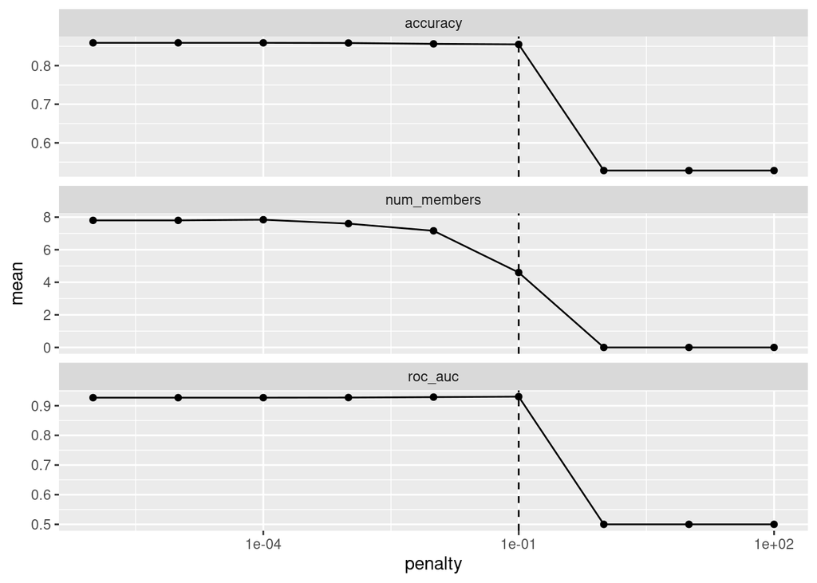

```r
autoplot(heart_model_st)
```

To show the relationship more directly:

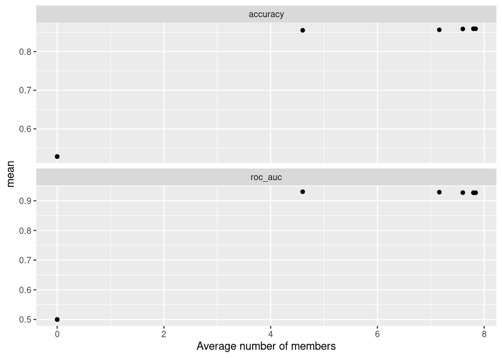

```r
autoplot(heart_model_st, type = "members")
```

To see the top results:

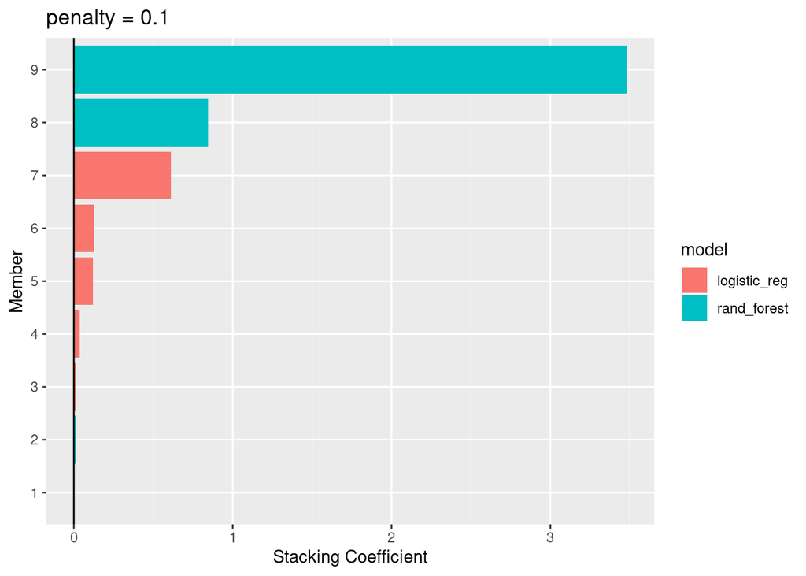

```r
autoplot(heart_model_st, type = "weights")
```

To identify which model configurations were assigned what stacking coefficients, we can make use of the `collect_parameters()` function:

```r
collect_parameters(heart_model_st, "rf_res")
```

```
# A tibble: 25 × 5
   member       mtry trees terms                   coef
   <chr>       <int> <int> <chr>                  <dbl>
 1 rf_res_1_01     1   100 .pred_Yes_rf_res_1_01 3.48
 2 rf_res_1_02     1   200 .pred_Yes_rf_res_1_02 0
 3 rf_res_1_03     1   300 .pred_Yes_rf_res_1_03 0
 4 rf_res_1_04     1   400 .pred_Yes_rf_res_1_04 0.0139
 5 rf_res_1_05     1   500 .pred_Yes_rf_res_1_05 0
 6 rf_res_1_06     2   100 .pred_Yes_rf_res_1_06 0
 7 rf_res_1_07     2   200 .pred_Yes_rf_res_1_07 0
 8 rf_res_1_08     2   300 .pred_Yes_rf_res_1_08 0
 9 rf_res_1_09     2   400 .pred_Yes_rf_res_1_09 0
10 rf_res_1_10     2   500 .pred_Yes_rf_res_1_10 0
# ℹ 15 more rows
```

**Python**

TODO

**Julia**

## 8 Final classification

```r
heart_pred <- Heart_test %>%
  bind_cols(predict(heart_model_st, ., type = "prob")) %>%
  print(width = Inf)
```

```
# A tibble: 76 × 16
     Age   Sex ChestPain    RestBP  Chol   Fbs RestECG MaxHR ExAng Oldpeak Slope
   <dbl> <dbl> <chr>         <dbl> <dbl> <dbl> <chr>   <dbl> <dbl>   <dbl> <dbl>
 1    63     1 typical         145   233     1 2         150     0     2.3     3
 2    67     1 asymptomatic    120   229     0 2         129     1     2.6     2
 3    37     1 nonanginal      130   250     0 0         187     0     3.5     3
 4    56     1 nontypical      120   236     0 0         178     0     0.8     1
 5    44     1 nontypical      120   263     0 0         173     0     0       1
 6    52     1 nonanginal      172   199     1 0         162     0     0.5     1
 7    48     1 nontypical      110   229     0 0         168     0     1       3
 8    64     1 typical         110   211     0 2         144     1     1.8     2
 9    60     1 asymptomatic    130   206     0 2         132     1     2.4     2
10    43     1 asymptomatic    150   247     0 0         171     0     1.5     1
      Ca Thal       AHD   .pred_No .pred_Yes
   <dbl> <chr>      <fct>    <dbl>     <dbl>
 1     0 fixed      No       0.478     0.522
 2     2 reversable Yes      0.125     0.875
 3     0 normal     No       0.750     0.250
 4     0 normal     No       0.855     0.145
 5     0 reversable No       0.704     0.296
 6     0 reversable No       0.697     0.303
 7     0 reversable Yes      0.617     0.383
 8     0 normal     No       0.527     0.473
 9     2 reversable Yes      0.107     0.893
10     0 normal     No       0.775     0.225
# ℹ 66 more rows
```

Computing the ROC AUC for the model:

```r
yardstick::roc_auc(
  heart_pred,
  truth = AHD,
  contains(".pred_No")
  )
```

```
# A tibble: 1 × 3
  .metric .estimator .estimate
  <chr>   <chr>          <dbl>
1 roc_auc binary         0.853
```

We can use the members argument to generate predictions from each of the ensemble members.

```r
heart_pred <-
  Heart_test |>
  select(AHD) |>
  bind_cols(
    predict(
      heart_model_st,
      Heart_test,
      type = "class",
      members = TRUE
      )
    ) |>
  print(width = Inf)
```

```
# A tibble: 76 × 11
   AHD   .pred_class .pred_class_logit_res_1_432 .pred_class_logit_res_1_433
   <fct> <fct>       <fct>                       <fct>
 1 No    Yes         No                          No
 2 Yes   Yes         Yes                         Yes
 3 No    No          No                          No
 4 No    No          No                          No
 5 No    No          No                          No
 6 No    No          No                          No
 7 Yes   No          Yes                         Yes
 8 No    No          No                          No
 9 Yes   Yes         Yes                         Yes
10 No    No          No                          No
   .pred_class_logit_res_1_434 .pred_class_logit_res_1_053
   <fct>                       <fct>
```

[output cut: 35 more lines]

```r
map(
  colnames(heart_pred),
  ~mean(heart_pred$AHD == pull(heart_pred, .x))
  ) |>
  set_names(colnames(heart_pred)) |>
  as_tibble() |>
  pivot_longer(c(everything(), -AHD))
```

```
# A tibble: 10 × 3
     AHD name                        value
   <dbl> <chr>                       <dbl>
 1     1 .pred_class                 0.737
 2     1 .pred_class_logit_res_1_432 0.789
 3     1 .pred_class_logit_res_1_433 0.789
 4     1 .pred_class_logit_res_1_434 0.789
 5     1 .pred_class_logit_res_1_053 0.763
 6     1 .pred_class_logit_res_1_054 0.776
 7     1 .pred_class_logit_res_1_055 0.763
 8     1 .pred_class_rf_res_1_01     0.737
 9     1 .pred_class_rf_res_1_04     0.737
10     1 .pred_class_rf_res_1_11     0.763
```